# When fitting goes wrong

PCB 6455 / BSC 4933: Biometry | Lecture 20

Dr. Brian Maitner

## Today’s agenda

- Tuesday: how to **notice** a fit that went wrong
- Today: how to **fix** it
- Four fixes: **centering**, **rescaling**, **keeping parameters legal**, and **good starting values**
- Plus: how to keep **one failed fit** from stopping a whole loop
- A challenge: **fix a broken model**

Type and run on a code block: type it into your script and run it. Code without the label is there to watch.

## The story so far

- An optimizer **searches** for the bottom of the NLL surface
- It can stop in the **wrong place** and still report `convergence = 0`
- **Today:** the four most common reasons, and the fix for each

## Get set up

```r
library(biometrydata)

occ <- bobwhite_occupancy
counts <- bobwhite_counts
reef <- reef_surveys

# bird traits: keep the columns we need, and drop species missing any of them
birds <- avonet[, c("Migration", "Range.Size", "Mass")]
birds <- na.omit(birds)
birds$migrant <- as.integer(birds$Migration == 3)    # 1 = long-distance migrant
```

Four datasets you know: occupancy by year, counts by route, reef surveys, and AVONET’s bird traits.

# Fix 1: center your covariates

## Same model, three ways to write the year

The occupancy model, $p = \text{logistic}(a + b \cdot \text{year})$, with “year” written three ways:

| Year as | $a$ means | Correlation of $a$ and $b$ | BFGS from (0, 0) |
| --- | --- | --- | --- |
| calendar year, 1997 to 2019 | occupancy in **year 0 AD** | effectively $-1$ | NLL **95.6**, `convergence` 0 |
| years since 1997 | occupancy in 1997 | -0.89 | NLL 56.69 |
| years from the middle year | occupancy in the **middle** year (2008) | -0.21 | NLL 56.69 |

**Same model. Same data.** With the calendar year, BFGS stops far from the bottom and reports success.

## Your turn: break it

```r
year_nll <- function(p, x){
  prob <- plogis(p[1] + p[2] * x)
  -sum(dbinom(occ$n_occupied, size = occ$n_routes,
              prob = prob, log = TRUE))
}

# the calendar year, as it comes in the data
fit_raw <- optim(c(0, 0), year_nll, x = occ$year,
                 method = "BFGS")
fit_raw$value
fit_raw$convergence
```

**Check:** an NLL of 95.6, with `convergence` 0. The bottom is at 56.69.

## Your turn: fix it

```r
# centered: subtract the mean year
occ$c_year <- occ$year - mean(occ$year)

fit_cen <- optim(c(0, 0), year_nll, x = occ$c_year,
                 method = "BFGS")
fit_cen$value
fit_cen$convergence
fit_cen$par
```

**Check:** 56.69, the true bottom, and a slope $b$ of -0.062, the same as Lecture 16’s.

## Why centering works

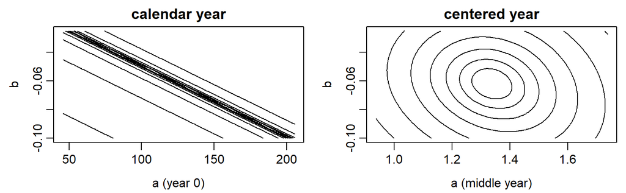

Left: a valley so narrow it is almost a line. Right: a round bowl.

Measure from the middle of your data, not from zero. The intercept then describes a year you actually observed, instead of a wild extrapolation two thousand years back, and the optimizer can find it.

# Fix 2: rescale

## Data that span orders of magnitude

**Are wide-ranging birds more likely to be long-distance migrants?** AVONET, 10,937 species. Range size runs from under 1 km² to 136 million km²; body mass from 2 g to 111 kg.

$$P(\text{migrant}) = \text{logistic}(a + b \cdot \text{range} + c \cdot \text{mass})$$

| Units | Nelder-Mead | BFGS |
| --- | --- | --- |
| km² and grams, as in the data | NLL **7,076**, `convergence` 0, range effect the **wrong sign** | **error**: `non-finite finite-difference value` |
| millions of km², kg | 3,177.95 | 3,177.95 |

**Same model.** In km², the range coefficient’s right value is about 0.00000005. A step that suits the intercept is ten million times too big for it.

## Your turn: change the units

```r
mig_nll <- function(p, range, mass){
  prob <- plogis(p[1] + p[2] * range + p[3] * mass)
  -sum(dbinom(birds$migrant, size = 1, prob = prob, log = TRUE))
}

fit_raw <- optim(c(0, 0, 0), mig_nll, range = birds$Range.Size, mass = birds$Mass)
fit_raw$par; fit_raw$value

fit_sc <- optim(c(0, 0, 0), mig_nll, range = birds$Range.Size / 1e6,
                mass = birds$Mass / 1000, method = "BFGS")
fit_sc$par; fit_sc$value
```

**Check:** 7,076 against 3,177.95. Which way does the range effect point in each?

Choose units that put your covariates roughly between 0.1 and 100. The model is unchanged; only the numbers the optimizer handles get easier.

# Fix 3: keep parameters legal

## Three ways, in order of preference

| Fix | How | Where you have used it |
| --- | --- | --- |
| **1. Transform** | fit the log of a positive parameter, the logit of a probability | Lecture 16’s table; every `exp(log_k)` since |
| **2. Bound** | `method = "L-BFGS-B"` with `lower` and `upper` | Lecture 16’s `size`; Tuesday’s challenge |
| **3. Penalize** | return a huge NLL for an illegal value | Lecture 16’s guard on the straight line |

Transforming is first because it **removes** the edge. Bounding stops at the edge. A penalty builds a **cliff**, which is exactly what Tuesday warned about.

Rewrite the parameter so no value is illegal, if you can. Fence it in if you cannot. Punish it only as a last resort.

## Worked example: an unprotected fit

**Where on Florida’s reefs do divers find the most fish species?** If richness peaks at some intermediate depth, the hump from Tuesday describes it: how many species at the peak, at what depth, and how fast richness falls away on either side. Here with every parameter on its **natural** scale:

```r
# p[1] peak richness, p[2] depth of the peak, p[3] width, p[4] negative binomial size
hump_nat <- function(p){
  mu <- p[1] * exp(-(reef$depth - p[2])^2 / (2 * p[3]^2))
  -sum(dnbinom(reef$richness, mu = mu, size = p[4], log = TRUE))
}

start <- c(25, 10, 20, 0.2)    # 25 species at 10 m, 20 m wide: a sensible guess
fit_nat <- optim(start, hump_nat, method = "BFGS")
fit_nat$value
fit_nat$par
```

11 warnings, `NaNs produced`. The answer: a peak of **39 species at 328 m**. The deepest survey is at 32 m.

## Fix it: transform

Fit the **log** of everything that must be positive, then `exp()` it back:

```r
hump_log <- function(p){
  mu <- exp(p[1]) * exp(-(reef$depth - p[2])^2 / (2 * exp(p[3])^2))
  -sum(dnbinom(reef$richness, mu = mu, size = exp(p[4]), log = TRUE))
}

# the same start, on the log scale
fit_log <- optim(c(log(25), 10, log(20), log(0.2)), hump_log, method = "BFGS")
fit_log$value

# back to the natural scale: peak, depth, width, size
c(exp(fit_log$par[1]), fit_log$par[2], exp(fit_log$par[3]), exp(fit_log$par[4]))
```

**Check:** NLL 31,752.34, a peak of 24.7 species at 16.1 m. No warnings.

## Fix it: bound

Keep the natural scale, and fence each positive parameter in:

```r
fit_bnd <- optim(start, hump_nat, method = "L-BFGS-B",
                 lower = c(peak  = 0.01,   # species at the peak: must be above 0
                           depth = 0,      # metres below the surface: not above it
                           width = 0.1,    # metres: must be above 0
                           size  = 0.01))  # clumping: must be above 0
fit_bnd$value
fit_bnd$par
```

**Why these limits:** each sits just above zero, where the model stops making sense, and far below any value the data would choose. The names are only labels, to remind you which is which; the order is what matters.

**Check:** NLL 31,752.34, a peak of 24.7 species at 16.1 m. No warnings, and no back-transforming.

## Fix it: penalize

Return a huge NLL whenever a value is illegal:

```r
hump_pen <- function(p){
  if (any(p[c(1, 3, 4)] <= 0)) {     # peak, width or size not positive
    return(1e10)                     # a terrible score: go somewhere else
  }
  hump_nat(p)
}

fit_pen_bfgs <- optim(start, hump_pen, method = "BFGS")
fit_pen_nm   <- optim(start, hump_pen)                   # Nelder-Mead
fit_pen_bfgs$value; fit_pen_nm$value
```

**Check:** BFGS puts the peak at **328 m** again (NLL 31,790.7). Nelder-Mead finds **24.7 species at 16.1 m** (NLL 31,752.35), the same hump as the transformed and bounded fits.

## All three, side by side

| Protection | Method | NLL | Peak at |
| --- | --- | --- | --- |
| none | BFGS | 31,790.7 | 328 m |
| **transform** | BFGS | **31,752.34** | 16.1 m |
| **bound** | L-BFGS-B | **31,752.34** | 16.1 m |
| penalize | BFGS | 31,790.7 | 328 m |
| penalize | Nelder-Mead | 31,752.35 | 16.1 m |

Transform first. Bounds also work. A penalty only works with a method that does not rely on slopes.

# When one fit fails

## A loop that dies on one bad fit

Lecture 16’s straight line, unguarded, from ten random starts:

```r
lin_nll <- function(p){
  prob <- p[1] + p[2] * occ$elapsed
  -sum(dbinom(occ$n_occupied, size = occ$n_routes, prob = prob, log = TRUE))
}

set.seed(20)
results <- rep(NA, 10)
for (i in 1:10) {                      # this loop fails on purpose
  start <- c(runif(1, 0.5, 1), runif(1, -0.03, 0.01))
  results[i] <- optim(start, lin_nll, method = "BFGS")$value
}
results
```

It stops at fit **3** with `initial value in 'vmmin' is not finite`. One impossible start ends the whole loop.

## `tryCatch()`: record the failure, keep going

```r
set.seed(20)
results <- rep(NA, 10)
for (i in 1:10) {
  start <- c(runif(1, 0.5, 1), runif(1, -0.03, 0.01))
  results[i] <- tryCatch(
    optim(start, lin_nll, method = "BFGS")$value,
    error = function(e){ NA }               # if it fails, record NA
  )
}
results
```

**8 of 10** fits succeed; the failures are `NA`, and the loop finishes.

tryCatch() says: try this, and if it throws an error, do this instead.

## Errors, warnings, and `try()`

An **error** stops your code. A **warning** prints a message and carries on.

|  | What it does |
| --- | --- |
| `try(code, silent = TRUE)` | runs the code; if it fails, returns a `"try-error"` object instead of stopping |
| `tryCatch(code, error = ..., warning = ...)` | lets you choose what happens on an error, on a warning, or both |

`try()` is the quick version:

```r
fit <- try(optim(start, lin_nll, method = "BFGS"), silent = TRUE)
if (inherits(fit, "try-error")) {
  cat("this start failed\n")
}
```

## `tryCatch()`, and a caution

`tryCatch()` is the flexible version: a separate response for errors and for warnings, and `finally =` for code that must run either way.

```r
result <- tryCatch(
  optim(start, lin_nll, method = "BFGS")$value,
  error = function(e){
    message("failed: ", conditionMessage(e))   # record WHY it failed
    NA
  }
)
```

Catching an error hides it. Keep a record of what failed, and if most attempts fail, fix the model rather than the loop.

# Fix 4: good starting values

## Where starting values come from

| Source | Example |
| --- | --- |
| **The plot** | read the reef peak off the graph: about 25 species at about 15 m |
| **A simpler model** | fit the nested model first; start the bigger one from its estimates |
| **A rough calculation** | method of moments, Lecture 15 |
| **A coarse grid** | for one or two parameters, Tuesday’s brute force |

## Build up from the simpler model

**Does development hurt bobwhite only past a threshold?** Tuesday’s challenge: counts stay flat until a route is a fraction $t$ developed, then fall. From Tuesday’s start, `optim()` slid to $t$ below zero, which means **no threshold at all**. Two models, one nested in the other:

```r
plain_nll <- function(p){            # counts fall from the first development
  mu <- exp(p[1] + p[2] * counts$frac_built)
  -sum(dnbinom(counts$count, mu = mu, size = exp(p[3]), log = TRUE))
}
threshold_nll <- function(p){        # counts flat until a fraction p[3] is built
  mu <- exp(p[1] + p[2] * pmax(0, counts$frac_built - p[3]))
  -sum(dnbinom(counts$count, mu = mu, size = exp(p[4]), log = TRUE))
}
```

With $t = 0$, the threshold model **is** the plain model.

## Start from the plain fit

```r
fit_plain <- optim(c(2, -1, 0), plain_nll)

# start exactly at the plain model: its estimates, with a threshold of 0
fit_built <- optim(c(fit_plain$par[1:2], 0, fit_plain$par[3]), threshold_nll)

fit_built$par[3]              # the threshold: fraction of the route developed
exp(fit_built$par[1])         # expected bobwhite on a route below the threshold
fit_built$value
```

**Check:** a threshold of **1.4%** developed, with about **11.8** bobwhite expected on a route below it (NLL 4,571.33, the best possible). Tuesday’s start stopped at a threshold of -0.1: no threshold at all.

The biology: there is a threshold, but it is **so close to zero** that there is effectively no safe level of development.

## What to try, in order

| You see | Likely cause | Try |
| --- | --- | --- |
| an error before it starts | a start that is illegal | a legal start; transform (Fix 3) |
| estimates that disagree between starts | false bottoms | more starts; build up (Fix 4) |
| estimates strongly correlated | a ridge | center (Fix 1) |
| coefficients differing a hundredfold | scales | rescale (Fix 2) |
| a curve that misses the data | any of the above | draw it, then work up this table |
| one failure stops a loop |  | `tryCatch()` |

# Challenge

## Challenge: fix this model

Reef richness against depth, $\text{depth}^2$, visibility and year, written the way data usually arrive:

```r
bad_nll <- function(p){
  mu <- exp(p[1] + p[2] * reef$depth + p[3] * reef$depth^2 +
            p[4] * reef$visibility + p[5] * reef$year)
  -sum(dnbinom(reef$richness, mu = mu, size = p[6], log = TRUE))
}

start <- c(3, 0, 0, 0, 0, 1)
first_try <- optim(start, bad_nll, method = "BFGS")
first_try$value
first_try$convergence
```

**Get the lowest NLL you can.** Same data, same model: change only how it is written. Note what you changed.

## How the room could have won

| The model with… | BFGS reaches |
| --- | --- |
| nothing changed | 35,754.6 |
| nothing changed, Nelder-Mead instead | 31,668.8 |
| **only** year centered | 33,659.1 |
| **only** depth and visibility rescaled | 35,030.3 |
| year centered **and** depth and visibility rescaled | **31,653.82** |

**One fix alone is not enough. Together, they reach the bottom.** And a completely different fitting routine, `MASS::glm.nb()`, agrees to the second decimal: 31,653.82.

Most failed fits have more than one cause. Fix what you can find, then check the answer a second, independent way.

## Before next class

Read Bolker **7.5**

Next time: **confidence limits** on things other than parameters, such as a fitted curve